# Assignment_12

### Portfolio assignment 12

30 min: Perform a bivariate analysis on at least 3 combinations of a numerical column with a categorical column in the dataset that you chose in portfolio assignment 4. Use *.groupby('columnname').mean()* to calculate the means. Is there a difference between categories? Then use seaborn barplots to check if there is a statistically significant difference.

```python
import pandas as pd
import seaborn as sns
```

```python
Pokemon = pd.read_csv("Pokemon.csv", sep=";")
```

```python
Pokemon.head()
```

|  | abilities | attack | capture_rate | classfication | defense | experience_growth | height_m | hp | name | percentage_male | pokedex_number | sp_attack | sp_defense | speed | type1 | type2 | weight_kg | generation | is_legendary |
| --- | --- | --- | --- | --- | --- | --- | --- | --- | --- | --- | --- | --- | --- | --- | --- | --- | --- | --- | --- |
| 0 | ['Rock Head', 'Sturdy', 'Sand Veil', 'Magnet P... | 80 | 255.0 | Rock Pokémon | 100 | 1059860 | 0 | 40 | Geodude | 50 | 74 | 30 | 30 | 20 | rock | ground | 0 | 1 | 0 |
| 1 | ['Stench', 'Sticky Hold', 'Poison Touch', 'Poi... | 80 | 190.0 | Sludge Pokémon | 50 | 1000000 | 0 | 80 | Grimer | 50 | 88 | 40 | 50 | 25 | poison | poison | 0 | 1 | 0 |
| 2 | ['Rock Head', 'Sturdy', 'Sand Veil', 'Magnet P... | 95 | 120.0 | Rock Pokémon | 115 | 1059860 | 0 | 55 | Graveler | 50 | 75 | 45 | 45 | 35 | rock | ground | 0 | 1 | 0 |
| 3 | ['Sand Veil', 'Sand Rush', 'Snow Cloak', 'Slus... | 75 | 255.0 | Mouse Pokémon | 90 | 1000000 | 0 | 50 | Sandshrew | 50 | 27 | 10 | 35 | 40 | ground | ice | 0 | 1 | 0 |
| 4 | ['Chlorophyll', 'Harvest', 'Frisk', 'Harvest'] | 105 | 45.0 | Coconut Pokémon | 85 | 1250000 | 0 | 95 | Exeggutor | 50 | 103 | 125 | 75 | 45 | grass | psychic | 0 | 1 | 0 |

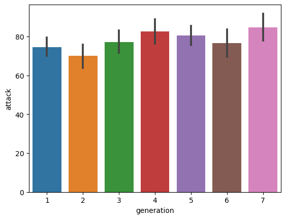

```python
sns.barplot(data=Pokemon, x='generation', y='attack')
```

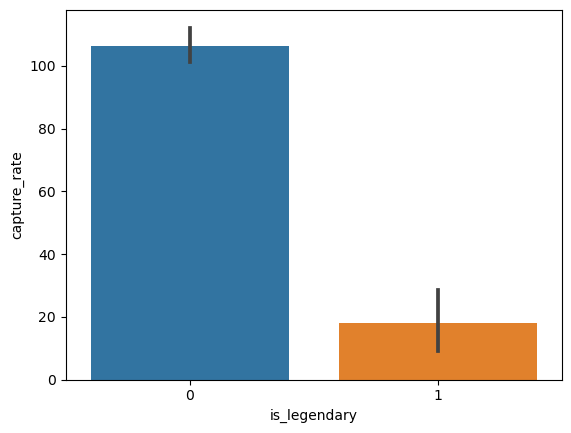

```python
sns.barplot(data=Pokemon, x='is_legendary', y='capture_rate')
```

```python
Pokemon.groupby('is_legendary')['capture_rate'].mean()
```

```
is_legendary
0    106.506849
1     17.985714
Name: capture_rate, dtype: float64
```

### Je kunt hieruit opmaken dat er een significant verschil zit tussen de vangst ratio van een legendarische en niet legendarische pokemon. Dit kun je opmaken aan de confidence interval, deze hebben absoluut geen overlap

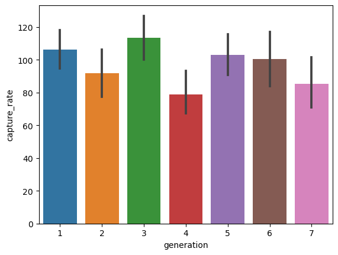

```python
sns.barplot(data=Pokemon, x='generation', y='capture_rate')
```

```python
Pokemon.groupby('generation')['capture_rate'].mean()
```

```
generation
1    106.185430
2     91.900000
3    113.355556
4     78.859813
5    103.102564
6    100.402778
7     85.202532
Name: capture_rate, dtype: float64
```

### Je kunt hieruit opmaken dat de gemiddelde vangst ratio voor een pokemon uit de 3e & 4e generatie significant verschillen met elkaar. Dit kun je opmaken uit de confidence interval die geen overlap hebben met elkaar.